# Поиск устойчивых последовательностей в верлибре

Борис Орехов

(НИУ ВШЭ, ИРЛИ РАН)

## Как изучать верлибр?

Мы уже знаем, как описывать и что искать в силлабо-тонике.

Это регулярный стих, поэтому стиховедов интересуют **распределение** форм регулярности и значимые **отклонения** от нее.

Примерно то же справедливо и для тоники.

Но что искать в верлибре? Это принципиально неурегулированный стих.

### Известное высказывание М. Л. Гаспарова

«Но методика исследования уже выработана, и здесь требуются только время и способные аспиранты».

Кажется, что не так все ясно, как это представлялось.

Все понятия и методики нужно уточнять или даже изобретать заново.

## Верлибр — это система

Единственная возможность изучать верлибр — это исходить из того, что он тоже является **системой**.

В таком случае мы сможем выявить конструктивные особенности этой системы, паттерны и отклонения.

Это не только филологический взгляд: “no verse is free for the man who wants to do a good job” *T. S. Eliot*

## В чем эта система?

Если в классических системах стихосложения мы можем найти систему в пределах одной строки, то верлибр становится таковым в сравнении с другими строками.

Следовательно, система в верлибре в соотношении строк между собой.

Частный случай соотношения — последовательность.

Примем гипотезу, что верлибры состоят из блоков схожих последовательностей строк.

“The distinguishing characteristic of free verse is the line as unit of rhythm” *Richard Andrews* A Prosody of Free Verse, 2017

## Что такое строка?

Вернее — что в строке релевантно для верлибра?

Строго говоря, мы этого не знаем, но можем предположить, что:

1. число слогов
2. распределение ударений
3. словоразделы
4. число слов в строке
5. частеречная характеристика слов?

Предположим, что из комбинаций этих параметров и складывается характеристика единиц, формирующих последовательность.

## Поработаем с данными

Возьмем 848 текстов, помеченных в НКРЯ как верлибры.

Это 29 131 строка.

Сначала сделаем вид, что всё это силлабика (будем мерить только длину строки в слогах).

## Обзор данных

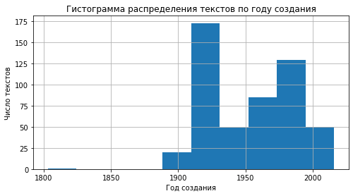

## Авторы

Ситуация с авторами разнообразная. Всего авторов 507.

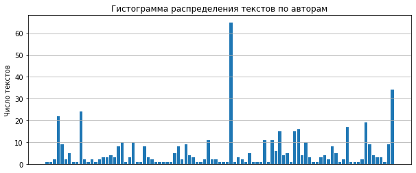

Чемпион в смысле текстов: Вениамин Блаженный (60+ произведений)

Здесь уместно вспомнить напоминание А. А. Илюшина относительно силлабики: это не обязательно изосиллабизм:

«вполне возможны и другие формы слогового порядка — не выравнивание количества, а, скажем, гармоничное сочетание разных количеств».

## GSP

Применим алгоритм generator sequential pattern.

```python
from prefixspan import PrefixSpan # импортируем библиотеку для GSP

db = [
    [0, 1, 2, 3, 4],  # данные для примера
    [1, 1, 1, 3, 4],
    [2, 1, 2, 2, 0],
    [1, 1, 1, 2, 2],
]

ps = PrefixSpan(db) # код для поиска паттернов

print(ps.frequent(2)) # выводим список паттернов с частотностью
                      # не меньше 2

# что получается:

[(2, [0]), (4, [1]), (3, [1, 2]), (2, [1, 2, 2]), (2, [1, 3]),
 (2, [1, 3, 4]), (2, [1, 4]), (2, [1, 1]),(2, [1, 1, 1]), (3, [2]),
 (2, [2, 2]), (2, [3]), (2, [3, 4]), (2, [4])]
```

## Силлабические паттерны из 4 и более строк

9-сложные строки в сочетании с 10- и 8-сложными

| Ранг | Паттерн | Частота |
| --- | --- | --- |
| 1 | 9, 9, 9, 9 | 255 |
| 2 | 9, 9, 9, 8 | 252 |
| 3 | 10, 9, 9, 9 | 251 |
| 4 | 10, 10, 9, 9 | 251 |
| 5 | 8, 8, 9, 9 | 246 |
| 6 | 9, 9, 9, 10 | 245 |
| 7 | 9, 8, 9, 8 | 243 |
| 8 | 8, 8, 9, 8 | 242 |
| 9 | 9, 9, 8, 9 | 240 |
| 10 | 7, 9, 9, 9 | 239 |

## Примеры

**9, 9, 9, 8**

а под нѐбом вита̀ет сова̀ --,  
оперѐнный большо̀й абажу̀р,  
и о̀чи совы̀ безразлѝчны,  
в ва̀шу ко̀мнату, где она̀...

*В.А. Соснора*. IV. ВОЗМЕЗДЬЕ

**9, 8, 9, 8**

Каждый ча̀с -- (я ведь то̀лько стра̀нник!)  
Слышу го̀рькое торжество̀  
И вѝжу, как хра̀м твой ру̀шится.  
Каждый ча̀с -- уко̀л и уда̀р

*Р. Ивнев (М.А. Ковалев)*. «Господи! За упоминанье...»

## Тонические паттерны

Для несиллабо-тонических строк НКРЯ размечен с точки зрения ударных и безударных слогов.

[figure not shown]

## Тонические паттерны

Разнообразие элементов больше, вероятность паттерна меньше.

В основном, строки по 3, 5, 7 слогов.

| Ранг | Паттерн | Частота |
| --- | --- | --- |
| 1 | 2*2*1, 1*2*1, 1*2*1, 1*2*1 | 24 |
| 2 | 1*2*1, 1*2*1, 0*2*1, 0*2*1 | 23 |
| 3 | 1*2*1, 1*2*1, 1*2*1, 1*2*1 | 23 |
| 4 | 2*2*1, 2*2*1, 1*2*1, 0*2*1 | 23 |
| 5 | 0*2*1, 0*2*1, 0*2*1, 0*2*1 | 22 |
| 6 | 1*2*1, 0*2*1, 0*2*1, 0*2*1 | 22 |
| 7 | 1*2*1, 1*2*1, 1*2*1, 0*2*1 | 22 |
| 8 | 2*2*1, 2*2*1, 1*2*1, 2*2*1 | 22 |
| 9 | 0*2*1, 0*2*1, 1*2*1, 1*2*1 | 21 |
| 10 | 1*1, 1*1, 1*1, 1*1 | 21 |

## Паттерны словоразделов

<sup>2</sup>Но̀ги <sup>2</sup>судьбы̀ <sup>2</sup>были <sup>3</sup>сдѐланы <sup>1</sup>из <sup>3</sup>зо̀лота. = '2|2|2|3|1|3'

<sup>2</sup>Живо̀т -- <sup>1</sup>из <sup>2</sup>блѐдных <sup>3</sup>рассвѐтных <sup>4</sup>освещѐний. = '2|1|2|3|4'

<sup>1</sup>Гру̀дь -- <sup>1</sup>из <sup>2</sup>стекла̀. = '1|1|2'

<sup>2</sup>Ру̀ки -- <sup>1</sup>из <sup>2</sup>ста̀ли. = '2|1|2'

*Б.Ю. Поплавский* «Ноги судьбы были сделаны из золота...»

## Паттерны словоразделов

Сверхкороткие дву- и трехсложные строки.

| Ранг | Паттерн | Частота |
| --- | --- | --- |
| 1 | 2, 2, 2, 2 | 29 |
| 2 | 2, 2, 2, 3 | 26 |
| 3 | 2, 2, 3, 3 | 26 |
| 4 | 2, 2, 2, 1\|2 | 25 |
| 5 | 2, 3, 2, 3 | 24 |
| 6 | 2, 1\|3, 2, 2 | 23 |
| 7 | 2, 2, 2, 2, 2 | 23 |
| 8 | 2, 2, 2\|2, 3 | 23 |
| 9 | 2, 3, 3, 3 | 23 |
| 10 | 2\|2, 2\|2, 3\|2, 3 | 23 |

## Промежуточные итоги

Силлабические паттерны наиболее перспективны.

Частотность несиллабических паттернов в 10 раз ниже, чем силлабических.

Нет смысла комбинировать характеристики, потому что тогда мы вообще не найдем никаких паттернов.

## Нечеткий поиск

Нужно вспомнить, что верлибр — это нерегулярный стих.

Следовательно, критерии для выделения паттернов должны быть мягче.

С этой точки зрения `8, 8, 12, 8` и `8, 8, 13, 8` — это один и тот же паттерн, а не два.

```python
from fuzzywuzzy import fuzz # библиотека для нечеткого поиска

string1 = 'ABCDEF'
string2 = 'ABCDEZ'
ratio = fuzz.ratio(string1, string2)
print(ratio) # значение сходства двух последовательностей
```

```
83
```

При $ratio > 79$ для шестистрочных последовательностей и при условии, что мы не ищем повторения паттернов в том же тексте, у нас находятся такие пары:

**10, 10, 10, 10, 9, 10** ⟷ **10, 10, 10, 11, 10, 10**

О, бу̀дь ты ря̀дом -- по̀ловца̀м-раба̀м  
несдо̀брова̀ть! Рассѐвшись шѝроко̀,  
мы б то̀ргова̀ли по̀ нога̀те ба̀б,  
по рѐзанѝ -- плюга̀вых му̀жико̀в!  
Га̀лицкий Осмомы̀сл Яросла̀в!  
Ты сто̀рожѝшь стара̀тельно̀ страну̀.  
*В.А. Соснора*. «В Киеве на горах...»

Где лежа̀т два ключа̀ золоты̀е:  
Первый клю̀ч от Могу̀щества Двѐри,  
А друго̀й от Воро̀т Воскрешѐнья...  
Боже, ско̀лько а̀лчущих скрѝпа пѐтель,  
Взмаха ство̀ров дверны̀х и воро̀тных,  
Миллио̀ны веко̀в у поро̀га,  
Как тума̀нов полкѝ над Помо̀рьем  
*Н.А. Клюев*. Поддонный псалом

Это простой случай, но заметно стилистическое родство текстов. Происхождение этого паттерна в условном былинно-говорном стихе.

## Максимально обобщенные паттерны

Длина 10 строк.

Состав элементов:

- Короткие строки: меньше 7 слогов
- Нормальные строки: от 7 до 10 слогов
- Длинные строки: от 11 до 15 слогов
- Сверхдлинные строки от 15 слогов

Запрет на однообразие.

## Две коротких, одна нормальная, семь коротких

| Длина | Текст 1 | Текст 2 |
| --- | --- | --- |
| Короткая | -- Кры̀лья коромы̀сла. | сила̀ч Проспѐро |
| Короткая | Свѝсло -- | Не бо̀йся Суо̀к! |
| Нормальная | О̀блако -- на небоскло̀н: -- | Усыпѝ гвардѐйца, вы̀мани клю̀ч, |
| Короткая | -- Освѐчены -- | откро̀й клѐтку. |
| Короткая | -- Края̀ | Смѐло скользѝ |
| Короткая | Его̀ клочко̀в | меж льво̀в и ко̀бр -- |
| Короткая | Огнѐм | тебя̀ привѐтствует |
| Короткая | И лѐтами | прозрѐвший наро̀д... |
| Короткая | -- Охва̀чены -- | Смотрѝ, Ирѝна! |
| Короткая | -- Трепѐщущим | У трѐх толстяко̀в |
| Короткая | *А. Белый*. Весенняя мелодия | *А. Е. Крученых*. «На черном небесном бархате...» |

Находится в 17 текстах

## Итоги

- Верлибр действительно свободный стих
- Повторяемость обнаруживается только при самых мягких ограничениях
- Возможные паттерны верлибра короткие, вероятно, аналог строфы
- Длина строки в слогах единственный осмысленный параметр для конструирования паттерна
- Что делает верлибр формально не отличимым от силабики